# ¶ Assignment 8: Split/Apply/Combine: Debt, the Last Seventy Years ¶

*Agenda*: Practicing split-apply-combine.

#### INSTRUCTIONS:

- Type each one of the R commands in this lesson on the space provided below.
- You can embed an R code chunk like this:

  ```r
  summary(cars)
  ```

  ```
  ##      speed           dist
  ##  Min.   : 4.0   Min.   :  2.00
  ##  1st Qu.:12.0   1st Qu.: 26.00
  ##  Median :15.0   Median : 36.00
  ##  Mean   :15.4   Mean   : 42.98
  ##  3rd Qu.:19.0   3rd Qu.: 56.00
  ##  Max.   :25.0   Max.   :120.00
  ```

- Before you move to the next step, highlight or move the cursor to the end of the individual R command and click on **Run**. Do this for all R commands.
- After you are done click the **Knit HTML**, **Knit PDF** button (upper left window). A document will be generated that includes both content as well as the output of any embedded R code chunks within the document.
- Go to File –> Save. Name your file.
- Upload the file to the Moodle site by using the link provided.

An important claim in economics is that the rate of GDP growth is closely related to the level of government debt, specifically with the ratio of the government’s debt to the GDP. The file `debt.csv`, located under the link that is labed Data file for Assignment 8, contains measurements of GDP growth and of the debt-to-GDP ratio for twenty countries around the world, from the 1940s to 2010. Note that not every country has data for the same years, and some years in the middle of the period are missing data for some countries but not others. Click on the Data file for assignment 8 download the file and upload to RStudio.

==========

##### Problem 1. (10 points)

Load the data into a dataframe called debt. You should have 1171 rows and 4 columns.

##### Solution

Type your answer here

```r
debt = read.csv("debt.csv")
str(debt)
```

```
## 'data.frame':    1171 obs. of  4 variables:
##  $ Country: chr  "Australia" "Australia" "Australia" "Australia" ...
##  $ Year   : int  1946 1947 1948 1949 1950 1951 1952 1953 1954 1955 ...
##  $ growth : num  -3.56 2.46 6.44 6.61 6.92 ...
##  $ ratio  : num  190 177 149 126 110 ...
```

##### Solution

Type your answer here

```r
average.growth = aggregate(growth ~ Country, data = debt, FUN = mean)
average.growth[average.growth$Country == "Australia", "growth"]
```

```
## [1] 3.721597
```

```r
average.growth[average.growth$Country == "Netherlands", "growth"]
```

```
## [1] 3.031161
```

```r
head(average.growth, 20)
```

```
##        Country   growth
## 1    Australia 3.721597
## 2      Austria 4.438030
## 3      Belgium 3.176287
## 4       Canada 3.652017
## 5      Denmark 2.656741
## 6      Finland 3.571897
## 7       France 3.776350
## 8      Germany 3.314818
## 9       Greece 2.927692
## 10     Ireland 3.933766
## 11       Italy 3.252528
## 12       Japan 4.447166
## 13 Netherlands 3.031161
## 14 New Zealand 3.069408
## 15      Norway 3.826671
## 16    Portugal 4.002797
## 17       Spain 3.196547
## 18      Sweden 3.065083
## 19          UK 2.414808
## 20          US 2.997120
```

##### Problem 3. (10 points)

Calculate the average GDP growth rate for each year (averaging over countries). Again, don’t use something like `mean(debt$growth[debt$Year==1972])` except to check your work. (The average growth rates for 1972 and 1989 should be $5.63$ and $3.19$, respectively.) Make a plot of the growth rates versus the year. Make sure the axes are labeled appropriately.

##### Solution

Type your answer here

```r
average.year = aggregate(growth ~ Year, data = debt, FUN = mean)
average.year[average.year$Year == 1972, "growth"]
```

```
## [1] 5.629986
```

```r
average.year[average.year$Year == 1989, "growth"]
```

```
## [1] 3.186842
```

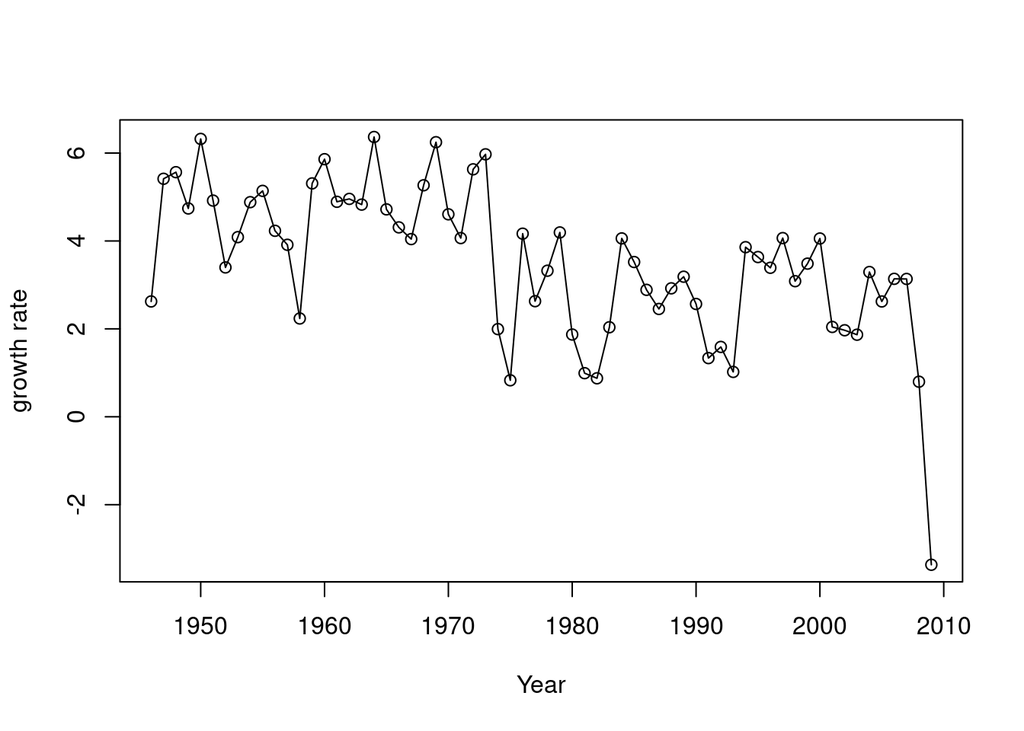

```r
plot(average.year$Year, average.year$growth, xlab = "Year", ylab = "growth rate", type = "o")
```

##### Problem 4. (10 points)

The function `cor(x,y)` calculates the correlation coefficient between two vectors `x` and `y`.

1. Calculate the correlation coefficient between GDP growth and the debt ratio over the whole data set (all countries, all years). Your answer should be $-0.1995$.

##### Solution

Type your answer here

```r
cor(debt$growth, debt$ratio)
```

```
## [1] -0.199468
```

2. Calculate the correlation coefficient separately for each country, and plot a histogram of these coefficients. The mean of these correlations should be $-0.1778$. Do not use a loop. *Hint*: consider writing a function and then making it an argument to `dplyr()`.

##### Solution

Type your answer here

```r
split_data = split(debt, debt$Country)


corr.calc = function(df) {
  if (nrow(df) > 1) {
    return(cor(df$growth, df$ratio))
  } else {
    return(NA)
  }
}


correlations = sapply(split_data, corr.calc)


correlations = na.omit(correlations)


mean.corr = mean(correlations)
mean.corr
```

```
## [1] -0.177822
```

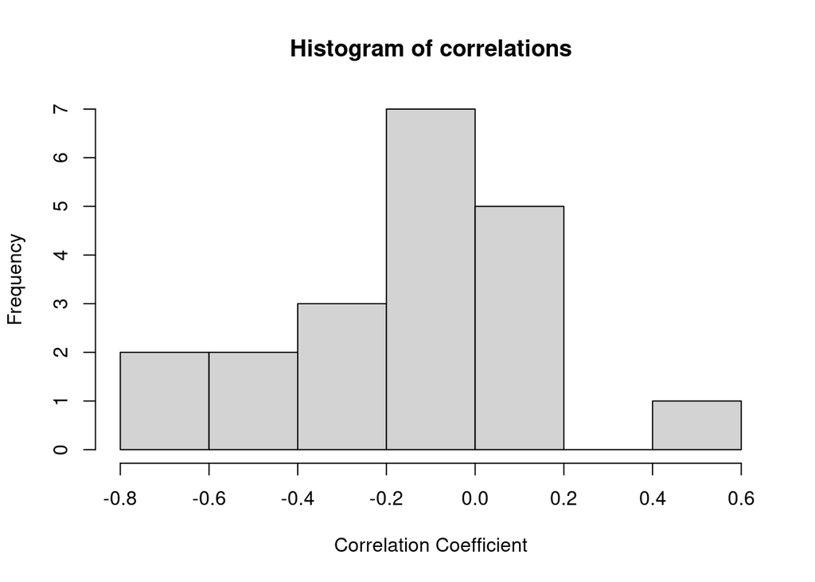

```r
hist(correlations, xlab = "Correlation Coefficient")
```

3. Calculate the correlation coefficient separately for each year, and plot a histogram of these coefficients. The mean of these correlations should be $-0.1906$.

##### Solution

Type your answer here

```r
split_data_by_year = split(debt, debt$Year)

correlations_by_year = sapply(split_data_by_year, corr.calc)
correlations_by_year = na.omit(correlations_by_year)

mean_correlation_by_year = mean(correlations_by_year)
mean_correlation_by_year
```

```
## [1] -0.1905526
```

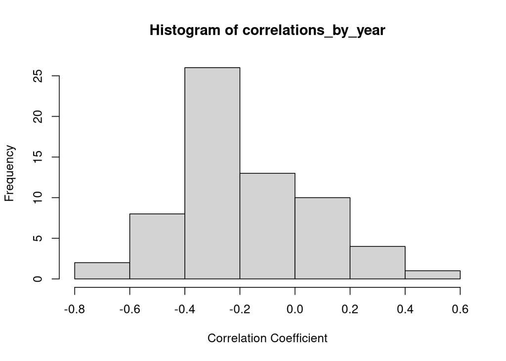

```r
hist(correlations_by_year, xlab = "Correlation Coefficient")
```

4. Are there any countries or years where the correlation goes against the general trend?

##### Solution

Type your answer here

```r
#countries that go against the trend
subset(data.frame(Country = names(correlations), Correlation = correlations, row.names = NULL), correlations > 0)
```

```
##        Country  Correlation
## 1    Australia 0.0251615558
## 4       Canada 0.0749755062
## 6      Finland 0.0005814147
## 14 New Zealand 0.1608454458
## 15      Norway 0.5629128534
## 17       Spain 0.0813828588
```

```r
#years that go against the trend
correlations_by_year[correlations_by_year > 0]
```

```
##        1950        1963        1971        1973        1974        1975
## 0.039754576 0.127811245 0.008717128 0.113716572 0.259851601 0.270698042
##        1977        1978        1981        1982        1988        1989
## 0.164476644 0.430658621 0.030394974 0.239084363 0.079662167 0.066371467
##        1990        1991        1995
## 0.155799702 0.202214712 0.051906462
```

##### Problem 5. (10 points)

Make a scatter-plot of GDP growth (vertical) against the debt ratio (horizontal). Describe the over-all shape of the point cloud in words. Does its shape match what you expect from problem 4?

##### Solution

Type your answer here

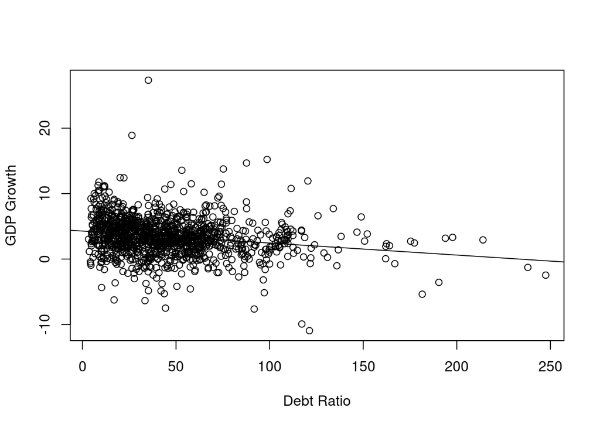

```r
plot(debt$ratio, debt$growth, xlab = "Debt Ratio", ylab = "GDP Growth")
abline(lm(debt$growth ~ debt$ratio))
```

```r
#from problem 4, the coefficient correlation should be around -0.2. so the plot should have a slight downward trend. from the added trend line, we can see that there is a slight downward trend. so as debt ratio goes up, gdp growth tends to go down slightly.
```

##### Total Number of Points Earned: XX/50